# Análise do Índice Firjan de Desenvolvimento Municipal entre 2013 e 2023

Cicero Filipe Rocha Da Silva

10 de dezembro de 2025

# 1 Introdução

O Índice FIRJAN de Desenvolvimento Municipal (IFDM) constitui uma das principais ferramentas de acompanhamento das condições socioeconômicas dos municípios brasileiros. Elaborado pela Federação das Indústrias do Estado do Rio de Janeiro (FIRJAN), o indicador sintetiza informações provenientes de bases oficiais e segmenta o desenvolvimento municipal em três dimensões: Educação, Saúde e Emprego & Renda. Este relatório concentra-se exclusivamente no IFDM Emprego & Renda, componente que mede a dinâmica do mercado de trabalho formal, a geração de ocupação e a evolução da massa salarial, refletindo diretamente o desempenho econômico local.Sendo convencionados quatro conceitos: municípios com IFDM entre 0,0 e 0,4: Desenvolvimento Crítico; municípios com IFDM entre 0,4 e 0,6: Desenvolvimento Baixo; municípios com IFDM entre 0,6 e 0,8: Desenvolvimento Moderado;municípios com IFDM entre 0,8 e 1,0: Desenvolvimento Alto.

A análise abrange o período de 2013 a 2023, permitindo observar tendências, assimetrias regionais e padrões de crescimento ou retração ao longo da última década. Com a utilização dos microdados consolidados do IFDM e técnicas de manipulação, visualização e sumarização de dados, este relatório busca apresentar uma leitura sistemática da evolução do índice nos municípios brasileiros.

Inicialmente, os dados foram reorganizados para estrutura de painel e tratados para garantir consistência estatística. Em seguida, são apresentadas estatísticas descritivas anuais, incluindo média, mediana, dispersão e valores extremos do IFDM, oferecendo uma visão geral do comportamento agregado do indicador. A análise gráfica da distribuição anual, por meio de violinos e boxplots, complementa essa leitura ao evidenciar a heterogeneidade entre municípios.

O relatório também identifica os 10 municípios com maior e menor desempenho em cada ano, permitindo comparar trajetórias e padrões persistentes tanto entre os melhores quanto entre os piores colocados. A partir da comparação entre 2013 e 2023, são destacados os municípios que mais avançaram e os que mais regrediram no período, oferecendo insights sobre dinâmicas locais de progresso ou deterioração.

Além disso, são exploradas diferenças espaciais por meio de gráficos de dispersão, análises da evolução da média estadual, densidade da distribuição do índice entre Unidades da Federação, e comparações por regiões do país. Mapas temáticos reforçam a dimensão territorial da análise, permitindo visualizar a distribuição geográfica do IFDM no início e no final do período estudado.

Combinando técnicas de análise descritiva, visualização avançada e organização espacial dos dados, este relatório fornece uma visão abrangente da evolução do IFDM Emprego & Renda no Brasil. Os resultados apresentados servem como base para interpretações sobre desigualdades regionais, dinâmicas econômicas municipais e mudanças estruturais que influenciam o mercado de trabalho no país.

# 2 Estatísticas Decritivas

Primeiro é criado uma tabela de estatísticas descritivas do IFDM Emprego & Renda por ano, incluindo média, mediana, desvio-padrão, mínimo e máximo, desconsiderando valores ausentes.

```r
# Estatísticas
tabela_estats <- ifdm_lgpt %>%
  group_by(ano) %>%
  summarise(
    media   = mean(ifdm, na.rm = TRUE),
    mediana = median(ifdm, na.rm = TRUE),
    sd      = sd(ifdm, na.rm = TRUE),
    minimo  = min(ifdm, na.rm = TRUE),
    maximo  = max(ifdm, na.rm = TRUE)
  )
```

A Tabela apresenta as estatísticas descritivas do IFDM Emprego & Renda para o período de 2013 a 2023. Observa-se uma tendência geral de crescimento na média do índice, que passou de aproximadamente 0,523 em 2013 para 0,586 em 2023, indicando uma melhora progressiva nas condições de emprego e renda nos municípios brasileiros. A mediana segue um padrão semelhante à média, sugerindo que a distribuição do índice é relativamente simétrica e não é fortemente influenciada por valores extremos.

O desvio-padrão se manteve relativamente estável ao longo da década, em torno de 0,20 a 0,23, o que evidencia que a variação entre municípios se manteve consistente. No entanto, a presença de valores mínimos baixos, embora ligeiramente crescentes, revela que ainda existem municípios com desempenho significativamente inferior, destacando persistentes desigualdades regionais. Por outro lado, o valor máximo do IFDM permaneceu próximo de 1 em boa parte dos anos, mostrando que alguns municípios já alcançaram o nível máximo do índice e mantêm desempenho elevado.

Estatísticas Descritivas do IFDM Emprego (2013–2023)

| Ano | Média | Mediana | Desvio-padrão | Mínimo | Máximo |
| --- | --- | --- | --- | --- | --- |
| 2013 | 0.523 | 0.509 | 0.229 | 0.073 | 1.000 |
| 2014 | 0.527 | 0.512 | 0.224 | 0.070 | 1.000 |
| 2015 | 0.522 | 0.512 | 0.212 | 0.101 | 1.000 |
| 2016 | 0.507 | 0.498 | 0.198 | 0.104 | 0.986 |
| 2017 | 0.509 | 0.499 | 0.200 | 0.106 | 0.989 |
| 2018 | 0.518 | 0.508 | 0.199 | 0.122 | 0.985 |
| 2019 | 0.524 | 0.511 | 0.201 | 0.127 | 1.000 |
| 2020 | 0.524 | 0.509 | 0.202 | 0.145 | 1.000 |
| 2021 | 0.552 | 0.543 | 0.217 | 0.110 | 1.000 |
| 2022 | 0.574 | 0.568 | 0.215 | 0.151 | 1.000 |
| 2023 | 0.586 | 0.581 | 0.213 | 0.155 | 1.000 |

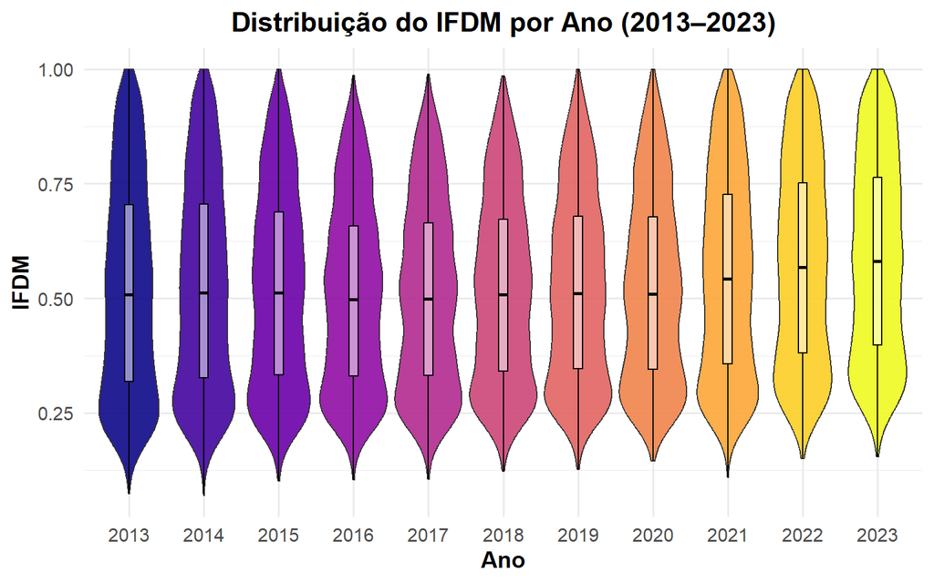

# 3 Ranking Dos Municípios

É criado um ranking que Identifica os 10 municípios com maior IFDM por ano, organiza em formato wide para visualização e formata a tabela para apresentação.

A tabela a seguir apresenta os dez municípios com melhor desempenho no IFDM Emprego & Renda em cada ano do período de 2013 a 2023. Observa-se que alguns municípios aparecem repetidamente entre os primeiros colocados, como Balneário Camboriú, Videira, Gramado, Campinas e Barueri, indicando consistência em seu desempenho econômico e na geração de emprego formal ao longo da década. Além disso, há uma diversidade geográfica, com municípios do Sul e Sudeste predominando, o que evidencia a concentração regional de bons resultados em termos de mercado de trabalho e renda formal. A análise dessa tabela permite identificar quais municípios apresentam trajetórias de destaque que podem servir de referência para estratégias de desenvolvimento em outras regiões do país.

Top 10 Municípios com Maior IFDM por Ano

| Ranking | Municípios por Ano 2013 | Municípios por Ano 2014 | Municípios por Ano 2015 | Municípios por Ano 2016 | Municípios por Ano 2017 | Municípios por Ano 2018 | Municípios por Ano 2019 | Municípios por Ano 2020 | Municípios por Ano 2021 | Municípios por Ano 2022 | Municípios por Ano 2023 |
| --- | --- | --- | --- | --- | --- | --- | --- | --- | --- | --- | --- |
| 1 | Campinas | Maringá | Balneário Camboriú | Balneário Camboriú | Salvador do Sul | Videira | Videira | Chapecó | Barueri | Campinas | Barueri |
| 2 | Ribeirão Preto | Pato Branco | Joaçaba | Gramado | Balneário Camboriú | Gramado | Gramado | Videira | Maringá | Curitiba | Curitiba |
| 3 | Maringá | Balneário Camboriú | Gramado | Botuverá | Timbó | Rio do Sul | Balneário Camboriú | Concórdia | Pato Branco | Maringá | Maringá |
| 4 | Balneário Camboriú | Blumenau | Videira | Bombinhas | Gramado | Salvador do Sul | Nova Trento | Salvador do Sul | Blumenau | Balneário Camboriú | Balneário Camboriú |
| 5 | Chapecó | Chapecó | Rio do Sul | Caçador | Botuverá | Balneário Camboriú | Chapecó | Rio do Sul | Chapecó | Blumenau | Blumenau |
| 6 | Joaçaba | Concórdia | Salvador do Sul | Concórdia | Fernando de Noronha | Concórdia | Concórdia | Marechal Cândido Rondon | Concórdia | Chapecó | Chapecó |
| 7 | Videira | Joaçaba | Nova Trento | Matelândia | Braço do Norte | Caçador | Içara | Nova Trento | Joaçaba | Concórdia | Concórdia |
| 8 | Gramado | Videira | Indaial | Rio Paranaíba | Luiz Alves | Marechal Cândido Rondon | Rio do Sul | São Miguel do Oeste | Gramado | Joaçaba | Joaçaba |
| 9 | Blumenau | Gramado | Cascavel | Ipumirim | Bombinhas | Braço do Norte | Timbó | Pato Branco | Videira | Gramado | Gramado |
| 10 | Salvador do Sul | Lajeado | Chapecó | Rio do Sul | Videira | Indaial | Caçador | Balneário Camboriú | Lajeado | Lajeado | Itirapina |

A tabela evidencia os dez municípios com menor desempenho no IFDM Emprego & Renda ao longo do período de 2013 a 2023. Nota-se uma forte concentração de municípios do Norte e Nordeste, especialmente do Maranhão, Piauí e Pará, refletindo desigualdades regionais persistentes no acesso a emprego formal e geração de renda. Municípios como Cachoeira Grande, Itaipava do Grajaú, Central do Maranhão e Presidente Sarney aparecem repetidamente entre os últimos colocados, indicando que enfrentam desafios estruturais e econômicos crônicos. A recorrência desses municípios na parte inferior do ranking sugere vulnerabilidades persistentes, como baixa diversificação econômica, menor infraestrutura e dificuldades em atrair investimentos. Essa análise permite compreender os padrões de atraso econômico e social, destacando áreas que poderiam se beneficiar de políticas públicas direcionadas para a melhoria do mercado de trabalho e da renda formal.

Top 10 Municípios com Menor IFDM por Ano

| Ranking | Municípios por Ano 2013 | Municípios por Ano 2014 | Municípios por Ano 2015 | Municípios por Ano 2016 | Municípios por Ano 2017 | Municípios por Ano 2018 | Municípios por Ano 2019 | Municípios por Ano 2020 | Municípios por Ano 2021 | Municípios por Ano 2022 | Municípios por Ano 2023 |
| --- | --- | --- | --- | --- | --- | --- | --- | --- | --- | --- | --- |
| 1 | Cachoeira Grande | Cachoeira Grande | Cachoeira Grande | Primeira Cruz | Central do Maranhão | Cachoeira Grande | Fartura do Piauí | Central do Maranhão | Pedro do Rosário | Ipixuna | Ipixuna |
| 2 | Marajá do Sena | Itaipava do Grajaú | Itaipava do Grajaú | Central do Maranhão | Apicum-Açu | Central do Maranhão | Primeira Cruz | Uiramutã | Buritirama | Presidente Sarney | Presidente Sarney |
| 3 | Brejo de Areia | Marajá do Sena | Beruri | Itaipava do Grajaú | Primeira Cruz | Uiramutã | Uiramutã | Maraã | Primeira Cruz | Cachoeira Grande | Jutaí |
| 4 | Itaipava do Grajaú | Beruri | Central do Maranhão | Beruri | Itaipava do Grajaú | Maraã | Central do Maranhão | Presidente Sarney | Cachoeira Grande | Nossa Senhora dos Remédios | Uiramutã |
| 5 | Cajapió | Cajapió | Presidente Sarney | Uiramutã | Cachoeira Grande | Itaipava do Grajaú | Maraã | Carnaubeira da Penha | Ipixuna | Primeira Cruz | Brejo de Areia |
| 6 | Curralinhos | São Roberto | São João do Carú | São Roberto | Uiramutã | Pedro do Rosário | Fernando Falcão | Primeira Cruz | Carnaubeira da Penha | Jutaí | Primeira Cruz |
| 7 | Pajeú do Piauí | Presidente Sarney | Marajá do Sena | Cachoeira Grande | São João do Carú | Primeira Cruz | Cachoeira Grande | Itaipava do Grajaú | Presidente Sarney | Uarini | Oeiras do Pará |
| 8 | São João do Soter | Primeira Cruz | São Roberto | Presidente Sarney | Beruri | Presidente Sarney | Carnaubeira da Penha | Ipixuna | Anamã | Canapi | Itaipava do Grajaú |
| 9 | Campo Alegre do Fidalgo | Jenipapo dos Vieiras | Jenipapo dos Vieiras | São João do Carú | Presidente Sarney | Junco do Maranhão | Pedro do Rosário | Vera Mendes | Uarini | Anamã | Bonfim do Piauí |
| 10 | Cedral | Cachoeira do Piriá | Cajapió | Luís Domingues | Araguanã | Araguanã | Presidente Sarney | Anamã | Nossa Senhora dos Remédios | Uiramutã | Cachoeira Grande |

# 4 Evolução dos Municípios no IFDM

O código calcula a variação do IFDM entre 2013 e 2023 para cada município, identifica os 10 municípios que mais cresceram e os 10 que mais caíram e formata tabelas de visualização.

```r
# Calcular IFDM inicial e final
df_variacao <- ifdm_lgpt %>%
  filter(ano %in% c(2013, 2023)) %>%
  pivot_wider(
    names_from = ano,
    values_from = ifdm,
    names_prefix = "ano_"
  ) %>%
  mutate(variacao = ano_2023 - ano_2013)

# Top 10 Cresceram
top10_crescimento <- df_variacao %>%
  arrange(desc(variacao)) %>%
  slice(1:10) %>%
  mutate(variacao = round(variacao, 3))

# Top 10 Cairam
top10_queda <- df_variacao %>%
  arrange(variacao) %>%
  slice(1:10) %>%
  mutate(variacao = round(variacao, 3))
```

Top 10 Municípios com Maior Crescimento no IFDM (2013–2023)

| Município | UF | IFDM 2013 | IFDM 2023 | Variação |
| --- | --- | --- | --- | --- |
| Primavera | PE | 0.2559 | 0.7254 | 0.470 |
| Trindade do Sul | RS | 0.5199 | 0.9490 | 0.429 |
| Pajeú do Piauí | PI | 0.1227 | 0.5356 | 0.413 |
| Três Arroios | RS | 0.5040 | 0.8977 | 0.394 |
| Quixeramobim | CE | 0.3331 | 0.7225 | 0.389 |
| Sebastião Leal | PI | 0.4437 | 0.8263 | 0.383 |
| Pereiro | CE | 0.3347 | 0.7057 | 0.371 |
| Aguiarnópolis | TO | 0.4465 | 0.8146 | 0.368 |
| Ipiaçu | MG | 0.5439 | 0.9114 | 0.367 |
| Novo Acordo | TO | 0.2850 | 0.6395 | 0.354 |

Os municípios que apresentaram maior queda no índice de Emprego & Renda entre 2013 e 2023 evidencia retrocessos significativos em algumas localidades, principalmente no Norte e Nordeste, embora também ocorram casos isolados em outras regiões do país. Municípios como Barra de Guabiraba (PE), Ferreira Gomes (AP) e Pedra Branca do Amapari (AP) registraram reduções superiores a 0,25 no índice, indicando deterioração considerável nas condições do mercado de trabalho formal e na geração de renda. Algumas dessas localidades, que inicialmente possuíam níveis relativamente altos de IFDM, como Altamira (PA) e Monções (SP), sofreram quedas expressivas, sugerindo mudanças adversas no dinamismo econômico local, possíveis perdas de empregos formais ou redução da massa salarial.

Top 10 Municípios com Maior Queda no IFDM (2013–2023)

| Município | UF | IFDM 2013 | IFDM 2023 | Variação |
| --- | --- | --- | --- | --- |
| Barra de Guabiraba | PE | 0.7580 | 0.3830 | -0.375 |
| Ferreira Gomes | AP | 0.7145 | 0.4445 | -0.270 |
| Pedra Branca do Amapari | AP | 0.7469 | 0.4788 | -0.268 |
| Jequiá da Praia | AL | 0.6688 | 0.4024 | -0.266 |
| Altamira | PA | 0.8805 | 0.6224 | -0.258 |
| Cortês | PE | 0.6577 | 0.4176 | -0.240 |
| Perobal | PR | 0.8670 | 0.6282 | -0.239 |
| Nova Santa Rita | PI | 0.5101 | 0.2720 | -0.238 |
| Nova América da Colina | PR | 0.7707 | 0.5439 | -0.227 |
| Monções | SP | 0.8895 | 0.6633 | -0.226 |

# 5 Dispersão dos Municípios

É criado um gráfico de dispersão comparando o IFDM de cada município em 2013 e 2023, destacando a linha de igualdade para facilitar a interpretação de evolução positiva ou negativa.

```r
df_disp <- ifdm_lgpt %>%
  filter(ano %in% c(2013, 2023)) %>%
  pivot_wider(
    names_from = ano,
    values_from = ifdm,
    names_prefix = "ano_"
  )
```

A análise da dispersão, indica uma forte correlação positiva, indicando que os municípios mantiveram, em grande medida, sua posição relativa no índice ao longo da década, aqueles com desenvolvimento alto em 2013 permaneceram com desempenho superior em 2023. No entanto, a análise dos dados confirma que a nuvem de pontos está predominantemente acima da linha de igualdade, demonstrando um avanço generalizado no desenvolvimento municipal. A maioria dos municípios registrou um aumento nominal em seus índices entre 2013 e 2023, o que sugere uma melhoria média na qualidade de vida e renda.

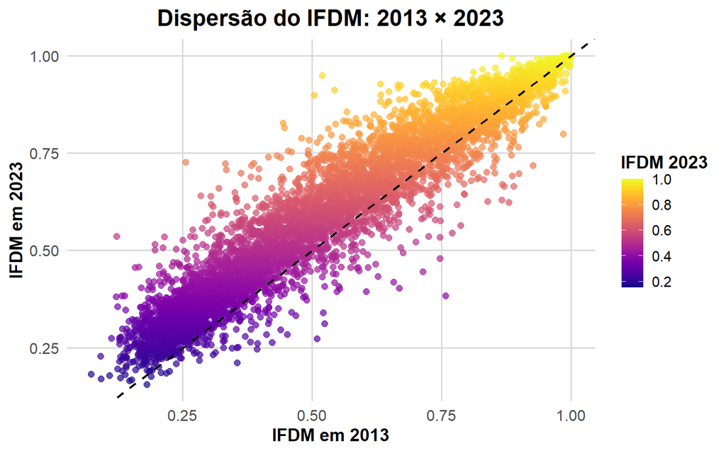

# 6 Evolução Média do índice por Estado

Calcula a média anual do IFDM para cada estado e cria um gráfico de densidade para visualizar a distribuição do índice por estado ao longo do período.

```r
media_estado <- ifdm_lgpt %>%
  group_by(sigla_uf, ano) %>%
  summarise(media_ifdm = mean(ifdm, na.rm = TRUE), .groups = "drop")
```

O gráfico de densidade de cristas, que mapeia a distribuição da média do IFDM para cada estado no período 2013-2023, visualiza a grande disparidade regional e a tendência de recuperação observada nos dados. As cristas mais à direita (maior IFDM), como DF, SC, MS, MT e SP, mostram uma distribuição em um patamar consistentemente mais alto, com desenvolvimento entre moderado e alto. Enquanto as cristas do Norte e Nordeste AM, MA, PI, estão agrupadas na extremidade esquerda, com maioria em desenvolvimento crítico. A forma alongada e o deslocamento da densidade para a direita em quase todas as cristas (particularmente de 2021 a 2023) confirmam que, apesar de uma fase de estagnação ou queda, a média do desenvolvimento brasileiro avançou na década, com quase todos os estados registrando um IFDM médio superior em 2023 em comparação a 2013.

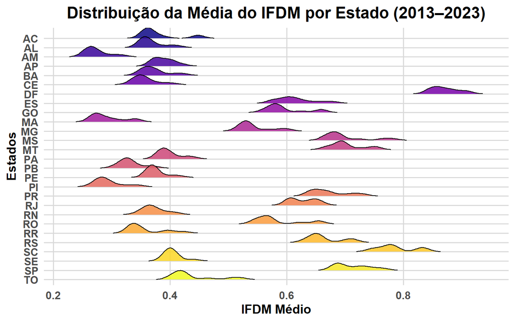

Calcula a média do IFDM de 2013 a 2023 para cada estado e apresenta em uma tabela organizada.

```r
# Media do Periodo para os Estados
media_periodo_estados <- ifdm_lgpt %>%
  group_by(sigla_uf) %>%
  summarise(media_ifdm_periodo = mean(ifdm, na.rm = TRUE)) %>%
  arrange(desc(media_ifdm_periodo))
```

Média do IFDM de Emprego e Renda por Estado (2013–2023)

| UF | IFDM Médio (2013–2023) |
| --- | --- |
| DF | 0.871 |
| SC | 0.786 |
| SP | 0.713 |
| MT | 0.703 |
| MS | 0.700 |
| PR | 0.672 |
| RS | 0.664 |
| RJ | 0.627 |
| ES | 0.614 |
| GO | 0.597 |
| RO | 0.583 |
| MG | 0.544 |
| TO | 0.438 |
| SE | 0.404 |
| PA | 0.398 |
| AP | 0.389 |
| AC | 0.380 |
| PE | 0.376 |
| BA | 0.373 |
| RN | 0.372 |
| AL | 0.368 |
| RR | 0.357 |
| CE | 0.357 |
| PB | 0.331 |
| PI | 0.293 |
| MA | 0.292 |
| AM | 0.274 |

# 7 Visão das Regiões

Agrupa estados por região, compara distribuições do IFDM por região utilizando boxplots, e formata visualmente o gráfico.

```r
df_regiao <- ifdm_lgpt %>%
  mutate(
    regiao = case_when(
      sigla_uf %in% c("AC","AP","AM","PA","RO","RR","TO") ~ "Norte",
      sigla_uf %in% c("AL","BA","CE","MA","PB","PE","PI","RN","SE") ~ "Nordeste",
      sigla_uf %in% c("DF","GO","MT","MS") ~ "Centro-Oeste",
      sigla_uf %in% c("ES","MG","RJ","SP") ~ "Sudeste",
      sigla_uf %in% c("PR","RS","SC") ~ "Sul"
    ))
```

A análise do IFDM por meio do gráfico de distribuição revela uma disparidade entre regiões. O Box Plot de Região demonstra uma polarização extrema, com o Sul, Centro-Oeste e Sudeste com medianas elevadas, com nível moderado próximo ao alto.Norte e Nordeste, com medianas significativamente baixas, com nível crítico. Embora Norte e Nordeste possuam outliers de alto desempenho, a concentração da massa de dados em patamares inferiores.

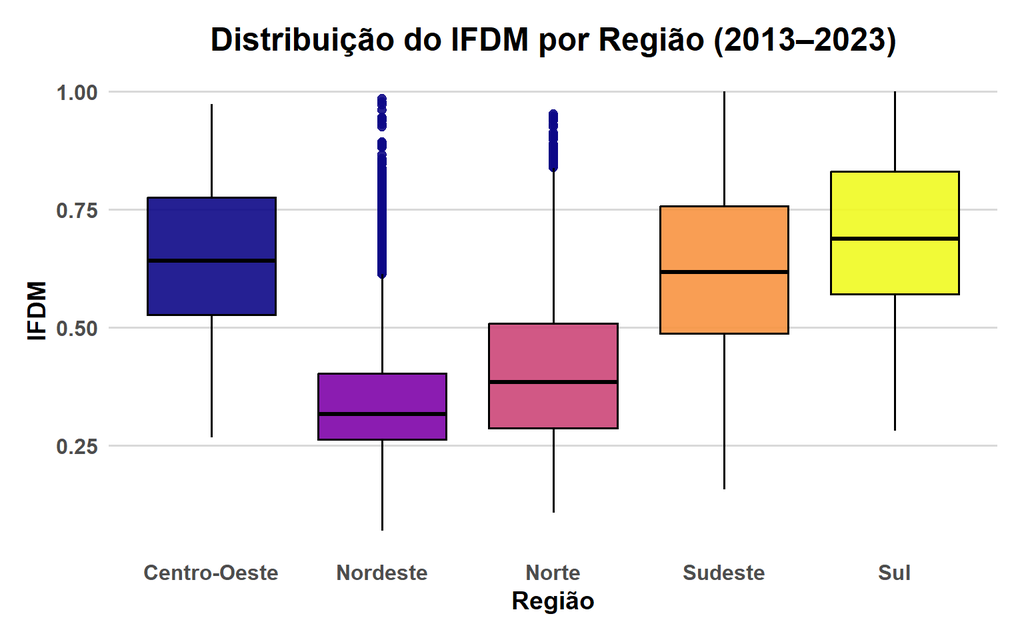

# 8 Mapas Municipais: 2013 x 2023

Carrega o mapa municipal do Brasil e faz join com o IFDM de 2013 e 2023, criando mapas temáticos que representam o índice em cada município.

```r
# Carregar mapa municipal
mapa <- read_municipality(year = 2023) %>%
  mutate(
    code_muni_7 = as.character(code_muni),
    code_muni = substr(code_muni_7, 1, 6)
  )

# Preparar
df_map <- ifdm_lgpt %>%
  filter(ano %in% c(2013, 2023)) %>%
  select(ano, cod_munic, ifdm) %>%
  mutate(code_muni = as.character(cod_munic)) %>%
  select(-cod_munic)

# Join
mapa_ifdm <- mapa %>%
  left_join(df_map, by = "code_muni")
```

A visualização espacial do IFDM Emprego & Renda para 2013 pode ser vista a seguir. Em 2013, observa-se que municípios do Sul e Sudeste apresentavam índices mais elevados, com destaque para estados como São Paulo, Santa Catarina e Distrito Federal, enquanto a maior parte do Norte e Nordeste registrava valores mais baixos.

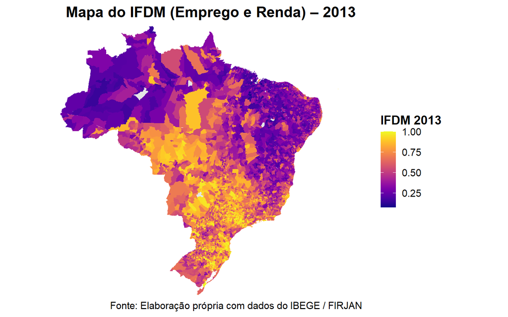

A visualização espacial do IFDM Emprego & Renda para 2023 pode ser vista a seguir. Nota-se uma leve tendência de melhora em diversos municípios no Nordeste e Norte, embora as diferenças regionais ainda permaneçam visíveis.

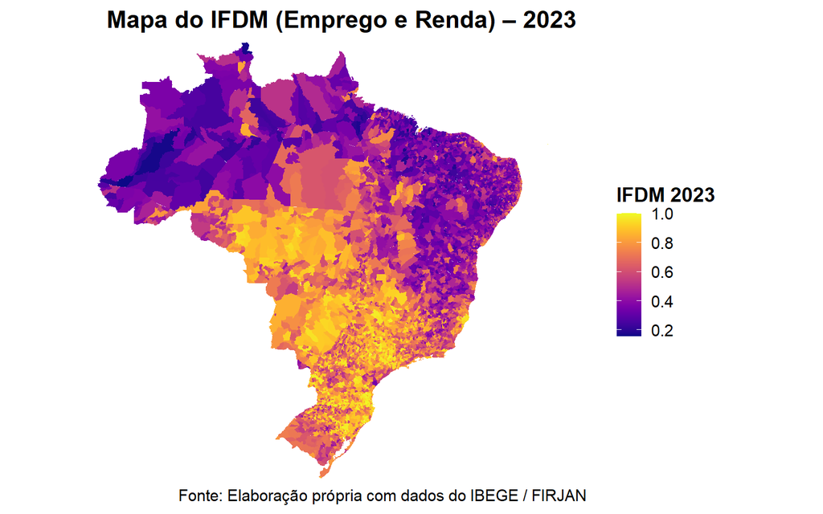

# 9 Apêndice

Abaixo é exposto todo o código utilizado para produção da análise.

```r
library(readxl)
library(dplyr)
library(tidyr)
library(janitor)
library(gt)
library(ggplot2)
library(forcats)
library(stringr)
library(knitr)
library(kableExtra)
library(ggridges)
library(viridis)
library(geobr)


Sys.setlocale("LC_ALL", "en_US.UTF-8")

##### Base #####
# Importando base de dados
IFDM_empregoerenda <- read_xlsx("C:/Users/dinoe/Downloads/IFDM/IFDMEmprego&Renda.xlsx")

# Verificando estrutura dos dados
str(IFDM_empregoerenda)

# Corrigindo Variáveis
IFDM_empregoerenda <- IFDM_empregoerenda %>%
  mutate(across(starts_with("Ranking"), ~as.numeric(.)),
         across(starts_with("IFDM"), ~as.numeric(.)))

# renomeando colunas
IFDM_empregoerenda <- IFDM_empregoerenda %>%
  clean_names()

#### Estatísticas Decritivas ####

# mudando estrutura dos dados
ifdm_lgpt <- IFDM_empregoerenda %>%
  pivot_longer(
    cols = starts_with("ifdm_emprego_"),
    names_to = "ano",
    values_to = "ifdm"
  ) %>%
  mutate(ano = readr::parse_number(ano)) %>%
  select(cod_munic,
         sigla_uf,
         nome_munic,
         ano,
         ifdm
         )

# Estatísticas
tabela_estats <- ifdm_lgpt %>%
  group_by(ano) %>%
  summarise(
    media   = mean(ifdm, na.rm = TRUE),
    mediana = median(ifdm, na.rm = TRUE),
    sd      = sd(ifdm, na.rm = TRUE),
    minimo  = min(ifdm, na.rm = TRUE),
    maximo  = max(ifdm, na.rm = TRUE)
  )

# Tabela de visualização Estatísticas Descritivas
tabela_descritiva <- tabela_estats %>%
  mutate(across(media:maximo, ~ round(.x, 3))) %>%
  kable(
    format = "html",
    caption = "Estatísticas Descritivas do IFDM Emprego (2013–2023)",
    align = "c",
    col.names = c("Ano", "Média", "Mediana", "Desvio-padrão", "Mínimo", "Máximo")
  ) %>%
  kable_styling(
    bootstrap_options = c("striped", "hover", "condensed"),
    full_width = FALSE,
    position = "center",
    font_size = 13
  ) %>%
  row_spec(0, bold = TRUE, background = "#E5E5E5") %>%
  column_spec(1, bold = TRUE) %>%
  column_spec(2:6, width = "10em")
tabela_descritiva


# Grafico distribuição para o IFDM
grafico_distribuicao <- ggplot(ifdm_lgpt, aes(x = factor(ano), y = ifdm, fill = factor(ano))) +
  geom_violin(alpha = 0.9) +
  geom_boxplot(width = 0.12, fill = "white", alpha = 0.5, color = "black") +
  scale_fill_viridis(discrete = TRUE, option = "plasma") +
  labs(
    title = "Distribuição do IFDM por Ano (2013–2023)",
    x = "Ano",
    y = "IFDM"
  ) +
  theme_minimal(base_size = 14) +
  theme(
    plot.title = element_text(hjust = 0.5, face = "bold"),
    axis.title = element_text(face = "bold"),
    legend.position = "none"
  )
grafico_distribuicao


#### Raking dos Melhores e Piores #####
### Top 10 melhores municípios por ano
top10_melhores <- ifdm_lgpt %>%
  group_by(ano) %>%
  arrange(desc(ifdm)) %>%
  slice(1:10) %>%
  ungroup()

# Tabela Top 10 melhores
top10_melhores <- top10_melhores %>%
  group_by(ano) %>%
  mutate(Ranking = row_number()) %>%
  ungroup() %>%
  select(Ranking, ano, nome_munic) %>%
  pivot_wider(
    names_from = ano,
    values_from = nome_munic
  ) %>%
  arrange(Ranking)

# tabela para visualização
tabela_top10melhores <- top10_melhores %>%
  kable(
    format = "html",
    caption = "Top 10 Municípios com Maior IFDM por Ano",
    align = "c",
    col.names = c("Ranking", names(top10_melhores)[-1])
  ) %>%
  kable_styling(
    bootstrap_options = c("striped", "hover", "condensed"),
    full_width = FALSE,
    font_size = 13,
    position = "center"
  ) %>%
  column_spec(1, bold = TRUE, width = "5em", color = "black") %>%
  column_spec(2:ncol(top10_melhores), width = "12em") %>%
  row_spec(0, bold = TRUE, background = "#E5E5E5") %>%
  add_header_above(c(" " = 1, "Municípios por Ano" = ncol(top10_melhores)-1))
tabela_top10melhores


### Top 10 piores municípios por ano
top10_piores <- ifdm_lgpt %>%
  group_by(ano) %>%
  arrange(ifdm) %>%
  slice(1:10) %>%
  ungroup()

# Tabela Top 10 piores
top10_piores <- top10_piores %>%
  group_by(ano) %>%
  mutate(Ranking = row_number()) %>%
  ungroup() %>%
  select(Ranking, ano, nome_munic) %>%
  pivot_wider(
    names_from = ano,
    values_from = nome_munic
  ) %>%
  arrange(Ranking)

# tabela para visualização
tabela_top10piores <- top10_piores %>%
  kable(
    format = "html",
    caption = "Top 10 Municípios com Menor IFDM por Ano",
    align = "c",
    col.names = c("Ranking", names(top10_piores)[-1])
  ) %>%
  kable_styling(
    bootstrap_options = c("striped", "hover", "condensed"),
    full_width = FALSE,
    font_size = 13,
    position = "center"
  ) %>%
  column_spec(1, bold = TRUE, width = "5em", color = "black") %>%
  column_spec(2:ncol(top10_piores), width = "12em") %>%
  row_spec(0, bold = TRUE, background = "#E5E5E5") %>%
  add_header_above(c(" " = 1, "Municípios por Ano" = ncol(top10_piores)-1))
tabela_top10piores


##### Evolução dos Municípios #####

# Calcular IFDM inicial e final
df_variacao <- ifdm_lgpt %>%
  filter(ano %in% c(2013, 2023)) %>%
  pivot_wider(
    names_from = ano,
    values_from = ifdm,
    names_prefix = "ano_"
  ) %>%
  mutate(variacao = ano_2023 - ano_2013)

# Top 10 Cresceram
top10_crescimento <- df_variacao %>%
  arrange(desc(variacao)) %>%
  slice(1:10) %>%
  mutate(variacao = round(variacao, 3))
# tabela
tabela_crescimento <- top10_crescimento %>%
  select(nome_munic, sigla_uf, ano_2013, ano_2023, variacao) %>%
  kable(
    format = "html",
    caption = "Top 10 Municípios com Maior Crescimento no IFDM (2013–2023)",
    col.names = c("Município", "UF", "IFDM 2013", "IFDM 2023", "Variação"),
    align = "c"
  ) %>%
  kable_styling(
    bootstrap_options = c("striped", "hover", "condensed"),
    full_width = FALSE,
    position = "center"
  ) %>%
  row_spec(0, bold = TRUE, background = "#E5E5E5") %>%
  column_spec(1, bold = TRUE, width = "15em") %>%
  column_spec(5, bold = TRUE)
tabela_crescimento

# Top 10 Cresceram
top10_queda <- df_variacao %>%
  arrange(variacao) %>%
  slice(1:10) %>%
  mutate(variacao = round(variacao, 3))
# tabela
tabela_queda <- top10_queda %>%
  select(nome_munic, sigla_uf, ano_2013, ano_2023, variacao) %>%
  kable(
    format = "html",
    caption = "Top 10 Municípios com Maior Queda no IFDM (2013–2023)",
    col.names = c("Município", "UF", "IFDM 2013", "IFDM 2023", "Variação"),
    align = "c"
  ) %>%
  kable_styling(
    bootstrap_options = c("striped", "hover", "condensed"),
    full_width = FALSE,
    position = "center"
  ) %>%
  row_spec(0, bold = TRUE, background = "#E5E5E5") %>%
  column_spec(1, bold = TRUE, width = "15em") %>%
  column_spec(5, bold = TRUE, color = "red")
tabela_queda
```

```r
##### Dispersão dos municipios IFDM 2013 x 2023 #####

df_disp <- ifdm_lgpt %>%
  filter(ano %in% c(2013, 2023)) %>%
  pivot_wider(
    names_from = ano,
    values_from = ifdm,
    names_prefix = "ano_"
  )

# Grafico
grafico_dispersao <- ggplot(df_disp, aes(x = ano_2013, y = ano_2023)) +
  geom_point(
    aes(color = ano_2023),
    alpha = 0.7,
    size = 2.2
  ) +
  scale_color_viridis(
    option = "plasma",
    name = "IFDM 2023"
  ) +
  geom_abline(
    intercept = 0, slope = 1,
    linetype = "dashed",
    color = "black",
    size = 0.8
  ) +
  labs(
    title = "Dispersão do IFDM: 2013 × 2023",
    x = "IFDM em 2013",
    y = "IFDM em 2023"
  ) +
  theme_minimal(base_size = 14) +
  theme(
    plot.title = element_text(face = "bold", hjust = 0.5, size = 18),
    plot.subtitle = element_text(hjust = 0.5, size = 13),
    axis.title = element_text(face = "bold", size = 14),
    axis.text = element_text(size = 12),
    legend.title = element_text(face = "bold"),
    panel.grid.minor = element_blank(),
    panel.grid.major = element_line(color = "gray85")
  )
grafico_dispersao

##### Evolução da Média do Indice por Estado #####

media_estado <- ifdm_lgpt %>%
  group_by(sigla_uf, ano) %>%
  summarise(media_ifdm = mean(ifdm, na.rm = TRUE), .groups = "drop")

# grafico
grafico_evo <- ggplot(media_estado, aes(x = media_ifdm, y = fct_rev(fct_inorder(sigla_uf)), fill = sigla_uf)) +
  geom_density_ridges(
    scale = 1.4,
    alpha = 0.85,
    rel_min_height = 0.01,
    color = "black",
    size = 0.4
  ) +
  scale_fill_viridis_d(option = "plasma") +
  labs(
    title = "Distribuição da Média do IFDM por Estado (2013–2023)",
    x = "IFDM Médio",
    y = "Estados"
  ) +
  theme_minimal(base_size = 14) +
  theme(
    legend.position = "none",
    plot.title = element_text(hjust = 0.5, face = "bold", size = 18),
    axis.title = element_text(face = "bold", size = 14),
    axis.text.y = element_text(face = "bold", size = 12),
    axis.text.x = element_text(face = "bold", size = 12),
    panel.grid.major = element_line(color = "gray85"),
    panel.grid.minor = element_blank()
  )
grafico_evo

# Media do Periodo para os Estados
media_periodo_estados <- ifdm_lgpt %>%
  group_by(sigla_uf) %>%
  summarise(media_ifdm_periodo = mean(ifdm, na.rm = TRUE)) %>%
  arrange(desc(media_ifdm_periodo))
# Tabela
media_periodo_estados %>%
  mutate(media_ifdm_periodo = round(media_ifdm_periodo, 3)) %>%
  kable("html", col.names = c("UF", "IFDM Médio (2013–2023)"),
        align = "c",
        caption = "Média do IFDM de Emprego e Renda por Estado (2013–2023)") %>%
  kable_styling(full_width = FALSE, bootstrap_options = c("striped", "hover")) %>%
  column_spec(1, width = "10em", bold = TRUE) %>%
  column_spec(2, width = "20em", bold = TRUE)


##### Região #######

df_regiao <- ifdm_lgpt %>%
  mutate(
    regiao = case_when(
      sigla_uf %in% c("AC","AP","AM","PA","RO","RR","TO") ~ "Norte",
      sigla_uf %in% c("AL","BA","CE","MA","PB","PE","PI","RN","SE") ~ "Nordeste",
      sigla_uf %in% c("DF","GO","MT","MS") ~ "Centro-Oeste",
      sigla_uf %in% c("ES","MG","RJ","SP") ~ "Sudeste",
      sigla_uf %in% c("PR","RS","SC") ~ "Sul"
    )
  )
# grafico
grafico_regi <- ggplot(df_regiao, aes(x = regiao, y = ifdm, fill = regiao)) +
  geom_boxplot(
    alpha = 0.9,
    color = "black",
    size = 0.6,
    outlier.color = viridis::viridis(1, option = "plasma"),
    outlier.size = 2.2
  ) +
  scale_fill_viridis_d(option = "plasma") +
  labs(
    title = "Distribuição do IFDM por Região (2013–2023)",
    x = "Região",
    y = "IFDM"
  ) +
  theme_minimal(base_size = 14) +
  theme(
    plot.title = element_text(face = "bold", hjust = 0.5, size = 18),
    plot.subtitle = element_text(hjust = 0.5, size = 13, color = "gray25"),
    axis.title = element_text(face = "bold"),
    axis.text.x = element_text(face = "bold", size = 12),
    axis.text.y = element_text(face = "bold", size = 12),
    panel.grid.major.x = element_blank(),
    panel.grid.major.y = element_line(color = "gray85"),
    panel.grid.minor = element_blank(),
    legend.position = "none",
    plot.margin = margin(15, 15, 15, 15)
  )
grafico_regi

##### Mapa Completo #####

# Carregar mapa municipal
mapa <- read_municipality(year = 2023) %>%
  mutate(
    code_muni_7 = as.character(code_muni),
    code_muni = substr(code_muni_7, 1, 6)
  )

# Preparar
df_map <- ifdm_lgpt %>%
  filter(ano %in% c(2013, 2023)) %>%
  select(ano, cod_munic, ifdm) %>%
  mutate(code_muni = as.character(cod_munic)) %>%
  select(-cod_munic)

# Join
mapa_ifdm <- mapa %>%
  left_join(df_map, by = "code_muni")

# Grafico 2013
mapa_2013 <- ggplot(mapa_ifdm %>% filter(ano == 2013)) +
  geom_sf(aes(fill = ifdm), color = NA) +
  scale_fill_viridis(
    name = "IFDM 2013",
    option = "plasma",
    na.value = "grey90"
  ) +
  labs(
    title = "Mapa do IFDM (Emprego e Renda) – 2013",
    caption = "Fonte: Elaboração própria com dados do IBEGE / FIRJAN"
  ) +
  coord_sf(datum = NA, expand = FALSE) +
  theme_minimal(base_size = 14) +
  theme(
    plot.title = element_text(face = "bold", hjust = 0.5),
    legend.title = element_text(face = "bold")
  )
mapa_2013

# Grafico 2023
mapa_2023 <- ggplot(mapa_ifdm %>% filter(ano == 2023)) +
  geom_sf(aes(fill = ifdm), color = NA) +
  scale_fill_viridis(
    name = "IFDM 2023",
    option = "plasma",
    na.value = "grey90"
  ) +
  labs(
    title = "Mapa do IFDM (Emprego e Renda) – 2023",
    caption = "Fonte: Elaboração própria com dados do IBEGE / FIRJAN"
  ) +
  coord_sf(datum = NA, expand = FALSE) +
  theme_minimal(base_size = 14) +
  theme(
    plot.title = element_text(face = "bold", hjust = 0.5),
    legend.title = element_text(face = "bold")
  )
mapa_2023
```